# Arkansas Field Data 2016

## Load in Data

Here we will import all of the necessary files. I will first import the counts table. This table was converted from the original biom file to a tab separated file. Next is the mapping file, which is the metadata. After that is the taxonomy file, which contains all of the taxonomies for the OTUs in the count table. The last file contains all of the OTUs that have been assigned as either plastid or mitochondria.

```r
library(lubridate)
library(tidyverse)
setwd("~/Google Drive/RMB/Analyses/ArkansasField/ARK16/FULLData/Data/")
```

```
The working directory was changed to /Users/edwards/Google Drive/RMB/Analyses/ArkansasField/ARK16/FULLData/Data inside a notebook chunk. The working directory will be reset when the chunk is finished running. Use the knitr root.dir option in the setup chunk to change the the working directory for no…
```

```r
counts <- read.table(gzfile("ark16_otutable.txt.gz"), header = T, row.names = 1, sep = "\t")
map <- read.table("../Data/ark16.map", header = T, sep = "\t") %>% mutate(Date = mdy(Date)) %>% mutate(Days = as.numeric(Date - min(Date)))
tax <- readRDS("gg_otus_tax.rds")
organelle_otus <- readRDS("organelle.rds")
```

## Remove organellar reads from the data

Mitochondria and plastids have 16S rRNA that gets sequenced along with the all of the other bacteria. These need to be removed, as they are not part of the microbiome.

## Make sure the mapping file is in the same order as the counts

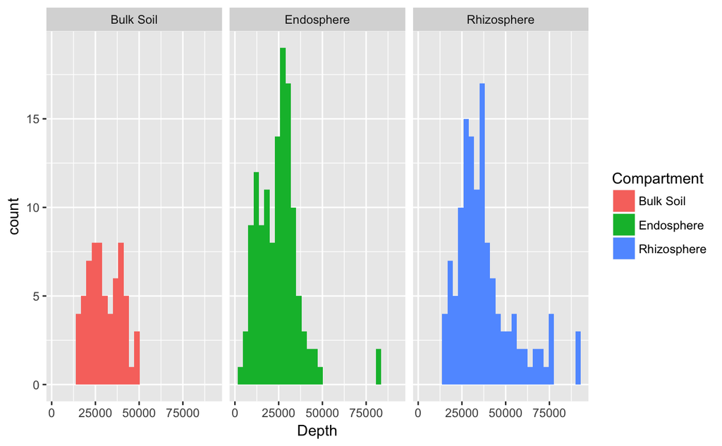

```r
map <- map[match(colnames(countsNoOrg), map$SampleID),]
map$Depth <- colSums(countsNoOrg)
map %>%
  ggplot(., aes(Depth, fill = Compartment)) +
  geom_histogram() +
  facet_grid(.~Compartment)
```

## Normalize the counts table

There are a few ways of normalizing counts. I will employ using relative abundance here. It’s pretty much just the looking at the percent of each microbe in each sample

## Remove OTUs that do not show up in 5% of the samples

I will remove microbes that do not show up regularly. These are noisy OTUs, and while they may be real, they most likely popped up through contamination, sequencing and PCR error. They make the downstream stats noisy, and so I will remove them.

```r
occurence <- function(x){
  return(length(x[x > 0]))
}
RA_clean <- RA[apply(RA, 1, occurence) >= ncol(RA) * 0.05,]
cat(nrow(RA), "OTUs in original table.\n")
```

```
21629 OTUs in original table.
```

```r
cat(nrow(RA_clean), "OTUs in cleaned table.\n")
```

```
11564 OTUs in cleaned table.
```

## Make a tidy version of the data

```r
library(reshape2)
ark.data <- melt(cbind(map, t(RA_clean)), id.vars = names(map)) %>%
  inner_join(tax, by = "variable")
```

```
joining factor and character vector, coercing into character vector
```

# Statistics

## Permanova

Permanova will tell you if an experimental factor is important for describing differences between your samples of multivariate data.

```r
adonis(t(log2(RA_clean + 1)) ~ Compartment + Days * Cultivar, strata = factor(map$Lane), data = map)
```

```
Call:
adonis(formula = t(log2(RA_clean + 1)) ~ Compartment + Days *      Cultivar, data = map, strata = factor(map$Lane))

Blocks:  strata
Permutation: free
Number of permutations: 999

Terms added sequentially (first to last)

               Df SumsOfSqs MeanSqs F.Model      R2 Pr(>F)
Compartment     2    24.085 12.0424  88.265 0.32437  0.001 ***
Days            1     5.777  5.7774  42.346 0.07781  0.001 ***
Cultivar        1     0.284  0.2844   2.085 0.00383  0.046 *
Days:Cultivar   2     1.402  0.7008   5.137 0.01888  0.001 ***
Residuals     313    42.704  0.1364         0.57512
Total         319    74.252                 1.00000
---
Signif. codes:  0 ‘***’ 0.001 ‘**’ 0.01 ‘*’ 0.05 ‘.’ 0.1 ‘ ’ 1
```

So now that we know that some of these factors are important, let’s go ahead and visualize the clustering patterns with PCoA.

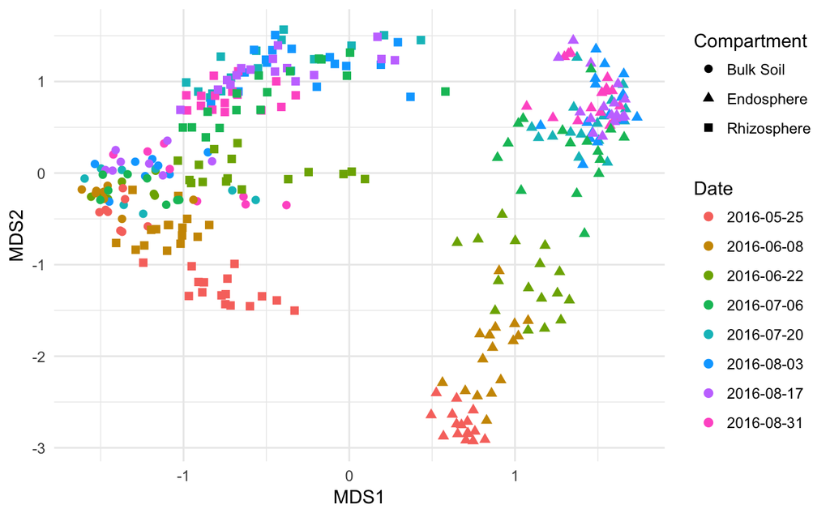

## Distribution of Phyla

You can play around with the different levels that you would like to look like. This code is finding the top 10 most abundant phyla (Proteobacteria is broken down to it’s various classes because it’s a super phylum) and plotting them out.

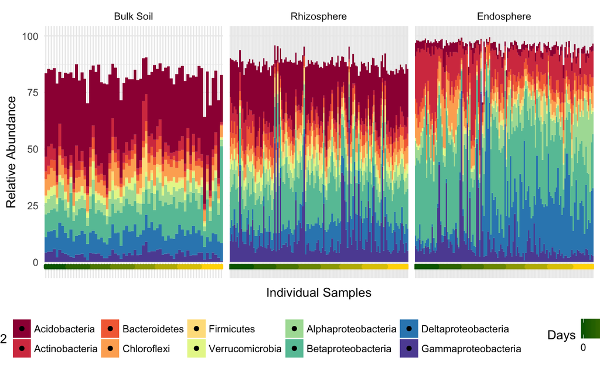

### Make a function to plot OTU abundance

```r
otu.plot <- function(., method = "lm"){
  ggplot(., aes(Days, value, color = Cultivar)) +
    geom_point() +
    geom_smooth(method = method, se = F) +
    facet_grid(.~Compartment) +
    scale_color_brewer(palette = "Accent")
}
```

I’m going to throw this section out eventually.

| variable | term | df | sumsq | meansq | statistic | p.value | p.adj | Kingdom | Phylum | Class | Order | Family | Genus | Species | Phylum2 |
| --- | --- | --- | --- | --- | --- | --- | --- | --- | --- | --- | --- | --- | --- | --- | --- |
| 3116297 | Compartment:Days | 2 | 2.150756e+02 | 1.075378e+02 | 6.172824e+01 | 2.461399e-23 | 9.754524e-20 | Bacteria | Proteobacteria | Deltaproteobacteria | Myxococcales | unclassified | unclassified | unclassified | Deltaproteobacteria |
| 827653 | Compartment:Days | 2 | 5.829623e+01 | 2.914811e+01 | 8.932202e+00 | 1.687056e-04 | 4.749062e-01 | Bacteria | Proteobacteria | Gammaproteobacteria | Aeromonadales | Aeromonadaceae | unclassified | unclassified | Gammaproteobacteria |
| 252876 | Compartment:Days | 2 | 9.341002e+00 | 4.670501e+00 | 6.014629e+00 | 2.733205e-03 | 1.000000e+00 | Bacteria | Proteobacteria | Betaproteobacteria | Burkholderiales | Comamonadaceae | Rubrivivax | gelatinosus | Betaproteobacteria |
| 562973 | Compartment:Days | 2 | 7.874848e+01 | 3.937424e+01 | 2.855060e+01 | 4.051851e-12 | 1.522281e-08 | Bacteria | Actinobacteria | Actinobacteria | Actinomycetales | Streptomycetaceae | Streptomyces | unclassified | Actinobacteria |
| 141531 | Compartment:Days | 2 | 6.047047e+01 | 3.023524e+01 | 1.847116e+01 | 2.605806e-08 | 9.128138e-05 | Bacteria | Proteobacteria | Betaproteobacteria | Burkholderiales | Comamonadaceae | unclassified | unclassified | Betaproteobacteria |
| 759624 | Compartment:Days | 2 | 1.209143e+02 | 6.045716e+01 | 8.311435e+01 | 1.073007e-29 | 4.274858e-26 | Bacteria | Proteobacteria | Betaproteobacteria | Burkholderiales | Oxalobacteraceae | unclassified | unclassified | Betaproteobacteria |
| 210951 | Compartment:Days | 2 | 7.092233e-01 | 3.546117e-01 | 6.416786e-01 | 5.270969e-01 | 1.000000e+00 | Bacteria | Acidobacteria | [Chloracidobacteria] | 11-24 | unclassified | unclassified | unclassified | Acidobacteria |
| 837574 | Compartment:Days | 2 | 1.308959e+01 | 6.544794e+00 | 2.922404e+00 | 5.526926e-02 | 1.000000e+00 | Bacteria | Proteobacteria | Gammaproteobacteria | Aeromonadales | Aeromonadaceae | unclassified | unclassified | Gammaproteobacteria |
| 658536 | Compartment:Days | 2 | 3.206999e+01 | 1.603500e+01 | 2.039799e+01 | 4.691387e-09 | 1.678109e-05 | Bacteria | Actinobacteria | Actinobacteria | Actinomycetales | unclassified | unclassified | unclassified | Actinobacteria |
| 557756 | Compartment:Days | 2 | 2.835005e+01 | 1.417502e+01 | 2.242059e+01 | 7.912228e-10 | 2.869765e-06 | Bacteria | Proteobacteria | Betaproteobacteria | Burkholderiales | Comamonadaceae | Rubrivivax | unclassified | Betaproteobacteria |

[output cut: 990 more lines]

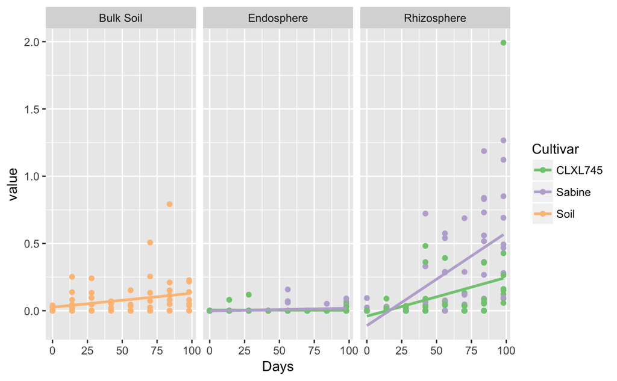

## Doing stats with negative binomial GLM

First requires that we have count data that is normalized. We will use rarefaction for this job. I hate this method because we have to throw away so much of the data. The minimum sequencing depth was 4384 sequences. We will randomly sample 4384 sequences from each sample.

```r
rare <- t(rrarefy(t(countsNoOrg), sample = min(colSums(countsNoOrg))))
rare.clean <- rare[apply(rare, 1, occurence) >= ncol(rare) * 0.05,]
rare.clean <- rare.clean[,match(map$SampleID, colnames(rare.clean))]
cat(nrow(rare), "OTUs in original table.\n")
```

```
21629 OTUs in original table.
```

```r
cat(nrow(rare.clean), "OTUs in cleaned table.\n")
```

```
6243 OTUs in cleaned table.
```

Just for fun I will also do the beta diversity stats here on this new dataset.

```r
adonis(t(log2(rareNoSoil + 1)) ~ Compartment*factor(Days)*Cultivar, strata = mapNoSoil$Lane, data = mapNoSoil)
```

```
Call:
adonis(formula = t(log2(rareNoSoil + 1)) ~ Compartment * factor(Days) *      Cultivar, data = mapNoSoil, strata = mapNoSoil$Lane)

Blocks:  strata
Permutation: free
Number of permutations: 999

Terms added sequentially (first to last)

                                   Df SumsOfSqs MeanSqs F.Model      R2 Pr(>F)
Compartment                         1    13.316 13.3162  91.007 0.20869  0.001 ***
factor(Days)                        7    11.471  1.6387  11.199 0.17977  0.001 ***
Cultivar                            1     0.290  0.2898   1.980 0.00454  0.031 *
Compartment:factor(Days)            7     3.322  0.4745   3.243 0.05206  0.001 ***
Compartment:Cultivar                1     0.190  0.1905   1.302 0.00299  0.156
factor(Days):Cultivar               7     1.429  0.2041   1.395 0.02239  0.015 *
Compartment:factor(Days):Cultivar   7     1.014  0.1448   0.990 0.01589  0.473
Residuals                         224    32.776  0.1463         0.51367
Total                             255    63.807                 1.00000
---
Signif. codes:  0 ‘***’ 0.001 ‘**’ 0.01 ‘*’ 0.05 ‘.’ 0.1 ‘ ’ 1
```

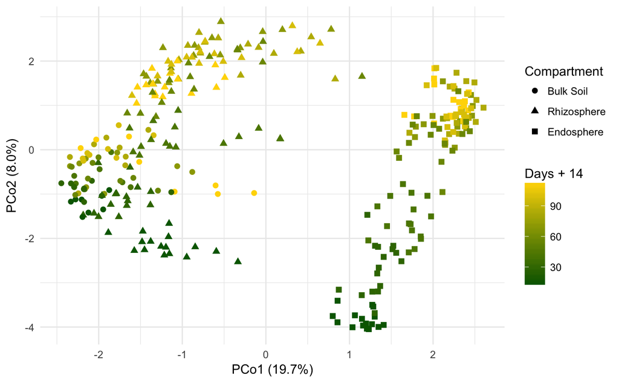

Here we will convert the data to the ‘long’ format.

```r
rare.data <- melt(cbind(map, t(rare.clean)), id.vars = names(map)) %>% inner_join(tax, by = "variable")
```